# Airplane Crash Data

Carlos Palomo

### Introduction

Since the first passenger flight in 1908, air travel has quickly became integrated into our society. Looking at a dataset of aircraft crashes from 1908 to 2009 collected by Socata, this analysis attempts to see if there is any correlation between fatalities and aircraft type, operator, route, location of takeoff, and how many people were aboard during the crash. As well see any other relevant statistics.

The first step was to clean the data. The records were include crashes across the world and both commercial and non-commercial accidents. To begin I separated out non-commercial and commercial crashes. Non-commercial crashes include military, governmental, and medical transports. Using boxplots, checked if there was any outliers within the numerical variables, Fatalities and Aboard.

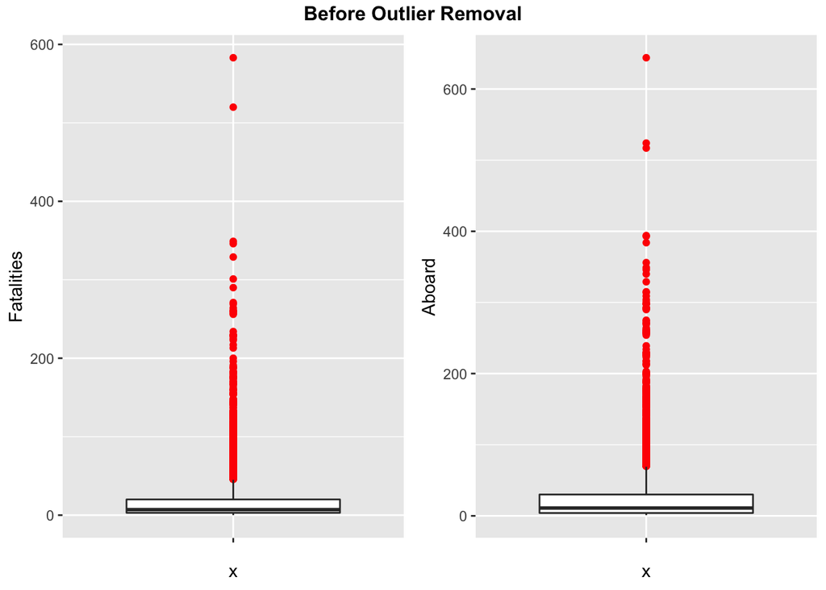

```
## 'data.frame':    1408 obs. of  9 variables:
##  $ Date      : Date, format: "1927-09-17" "1928-06-22" ...
##  $ Location  : chr  "Hadley, New Jersey" "Lebo, Kansas" "Near Port Townsend, BC, Canada" "Spur, Texas" ...
##  $ Operator  : chr  "Reynolds Airways" "National Air Transport" "British Columbia Airways" "Sunbeam Air Transport Co." ...
##  $ Route     : chr  "Sightseeing" "Chicago - Dallas" "Victoria - Seattle" "San Antonio - Amarillo - Tulsa - Denver" ...
##  $ Type      : chr  "Fokker F-VII" "Douglas M-4" "Ford 4-AT-B Tri Motor" "Ford 4-AT-B Tri Motor" ...
##  $ Aboard    : int  12 1 7 5 1 15 8 2 4 16 ...
##  $ Fatalities: int  7 1 7 5 1 14 8 1 4 16 ...
##  $ non_com   : chr  "False" "False" "False" "False" ...
##  $ year      : num  1927 1928 1928 1928 1928 ...
##  - attr(*, "na.action")= 'omit' Named int [1:1179] 1 2 3 4 5 6 7 8 9 11 ...
##   ..- attr(*, "names")= chr [1:1179] "1" "2" "3" "4" ...
```

### Analysis

To begin I examined the Fatalities and amount of people Aboard again. This time using a bar to view a yearly breakdown. On average the amount fatalities is 11 people, where the average amount of people on board is 14 people. Giving a proportion 78.6% of people death within air craft crashes.

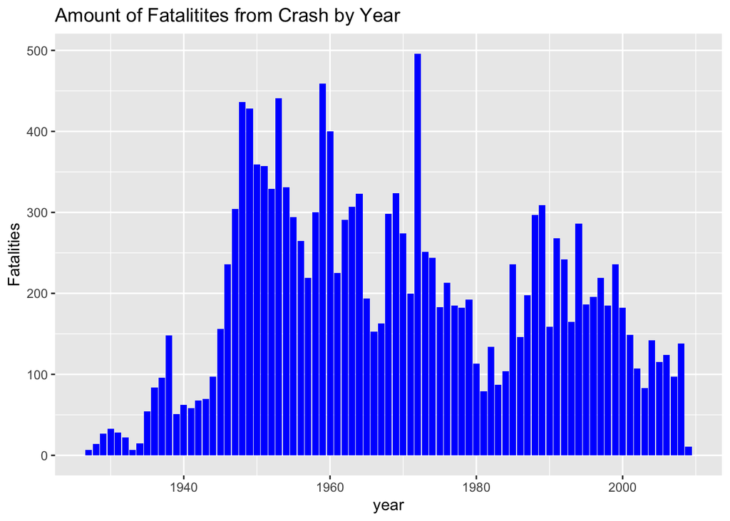

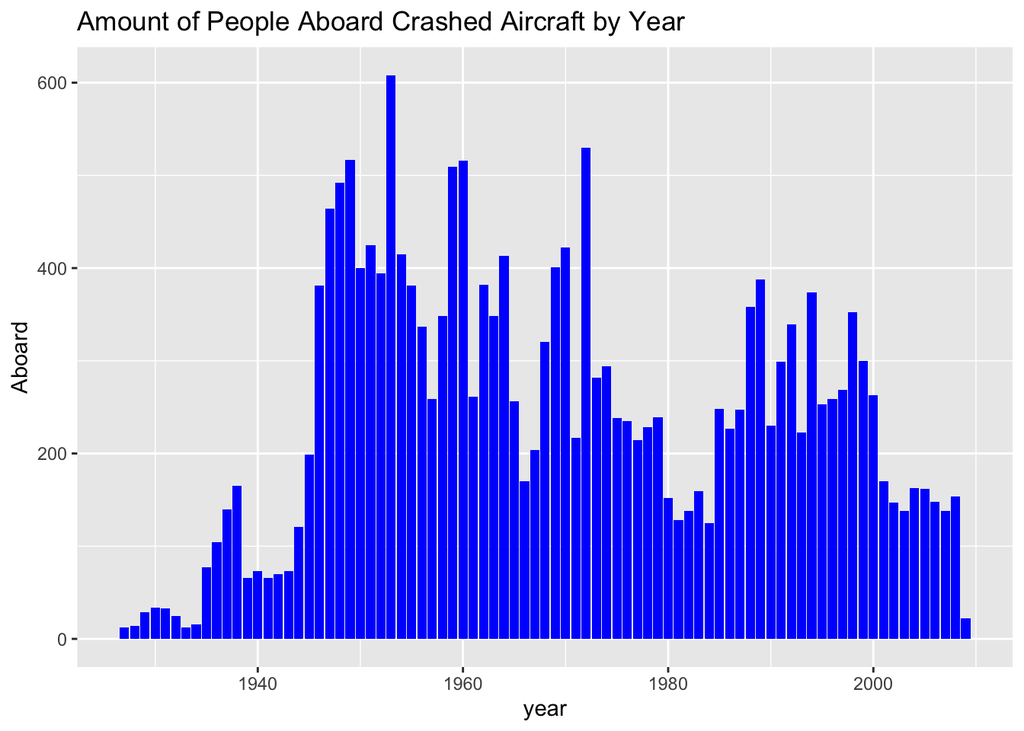

#### Categorical Variables

```
##
##  Pearson's Chi-squared test
##
## data:  table(commerical_crash$Operator, commerical_crash$Location)
## X-squared = 1208094, df = 1197282, p-value = 1.624e-12
```

```
##
##  Pearson's Chi-squared test
##
## data:  table(commerical_crash$Operator, commerical_crash$Route)
## X-squared = 1264800, df = 1248150, p-value < 2.2e-16
```

```
##
##  Pearson's Chi-squared test
##
## data:  table(commerical_crash$Operator, commerical_crash$Type)
## X-squared = 263055, df = 234558, p-value < 2.2e-16
```

```
##
##  Pearson's Chi-squared test
##
## data:  table(commerical_crash$Location, commerical_crash$Route)
## X-squared = 1694719, df = 1684075, p-value = 3.561e-09
```

```
##
##  Pearson's Chi-squared test
##
## data:  table(commerical_crash$Location, commerical_crash$Type)
## X-squared = 316496, df = 316479, p-value = 0.491
```

```
##
##  Pearson's Chi-squared test
##
## data:  table(commerical_crash$Route, commerical_crash$Type)
## X-squared = 329943, df = 329925, p-value = 0.4906
```

Due to the amount of levels in the categorical variables it is difficult straight forward regression model. To start with I created a simple linear model with only the Operator, Type, and Location. I then tested to to see if any variable should be dropped. From run it appears that we should keep all variables. In order to better understanding I then generated an ANOVA to verify that that each variable is relevant.

```
## Start:  AIC=-3369.92
## Fatalities ~ Operator + Type + Location
##
##             Df Sum of Sq     RSS     AIC
## <none>                      17.5 -3369.9
## - Type       9     667.7   685.2  1776.0
## - Operator  26    2312.3  2329.8  3465.1
## - Location 299   30513.8 30531.3  6541.8
```

|  | Df | Sum Sq | Mean Sq | F value | Pr(>F) |
| --- | --- | --- | --- | --- | --- |
| Operator | 942 | 113605.08 | 120.5999 | 27.56569 | 0.002512946 |
| Type | 162 | 20950.64 | 129.3250 | 29.55999 | 0.002212797 |
| Location | 299 | 30513.79 | 102.0528 | 23.32636 | 0.003492784 |
| Residuals | 4 | 17.50 | 4.3750 | NA | NA |

From the summary of the R-squared value is 99.99%. Because this number is nearly perfect it leads to believe that there is any issue with the data and model. This is mostly being caused the amount of levels with each categorical variables. Which leads me to doubt the model.

#### Numerical Variable

```
##
## Call:
## lm(formula = Fatalities ~ Aboard, data = commerical_crash)
##
## Residuals:
##     Min      1Q  Median      3Q     Max
## -33.269  -0.316   0.764   3.063   9.961
##
## Coefficients:
##             Estimate Std. Error t value Pr(>|t|)
## (Intercept)  0.38560    0.25303   1.524    0.128
## Aboard       0.77008    0.01376  55.976   <2e-16 ***
## ---
## Signif. codes:  0 '***' 0.001 '**' 0.01 '*' 0.05 '.' 0.1 ' ' 1
##
## Residual standard error: 6.031 on 1406 degrees of freedom
## Multiple R-squared:  0.6903, Adjusted R-squared:   0.69
## F-statistic:  3133 on 1 and 1406 DF,  p-value: < 2.2e-16
```